# Drugs Relationship on Depression

```r
view(DrugOnDepFinal)
```

DATA STRUCTURE

```r
#install.packages("skimr")
library(skimr)

skim(DrugOnDepFinal)
```

Data summary

| Name | DrugOnDepFinal |
| --- | --- |
| Number of rows | 4572 |
| Number of columns | 48 |
| _______________________ |  |
| Column type frequency: |  |
| numeric | 48 |
| ________________________ |  |
| Group variables | None |

**Variable type: numeric**

| skim_variable | n_missing | complete_rate | mean | sd | p0 | p25 | p50 | p75 | p100 | hist |
| --- | --- | --- | --- | --- | --- | --- | --- | --- | --- | --- |
| SEQN | 0 | 1 | 98278.97 | 2690.96 | 93705 | 95949.50 | 98268.50 | 100601.00 | 102956 | ▇▇▇▇▇ |
| GENDER | 0 | 1 | 1.52 | 0.50 | 1 | 1.00 | 2.00 | 2.00 | 2 | ▇▁▁▁▇ |
| AGEYR | 0 | 1 | 44.25 | 15.47 | 18 | 31.00 | 45.00 | 59.00 | 69 | ▇▆▆▆▇ |
| Race | 0 | 1 | 0.24 | 0.43 | 0 | 0.00 | 0.00 | 0.00 | 1 | ▇▁▁▁▂ |
| RIDEXAGM | 0 | 1 | 13.05 | 52.97 | 0 | 0.00 | 0.00 | 0.00 | 239 | ▇▁▁▁▁ |
| EDUC | 1 | 1 | 0.54 | 0.50 | 0 | 0.00 | 1.00 | 1.00 | 1 | ▇▁▁▁▇ |
| MARTL | 0 | 1 | 0.47 | 0.50 | 0 | 0.00 | 0.00 | 1.00 | 1 | ▇▁▁▁▇ |
| INCOME | 0 | 1 | 0.78 | 0.41 | 0 | 1.00 | 1.00 | 1.00 | 1 | ▂▁▁▁▇ |
| POVRAT | 0 | 1 | 2.17 | 1.75 | 0 | 0.74 | 1.73 | 3.66 | 5 | ▇▆▃▂▆ |
| DPINTEREST | 0 | 1 | 0.37 | 0.80 | 0 | 0.00 | 0.00 | 0.00 | 9 | ▇▁▁▁▁ |
| DPFEEL | 0 | 1 | 0.34 | 0.74 | 0 | 0.00 | 0.00 | 0.00 | 9 | ▇▁▁▁▁ |
| DPSLEEP | 0 | 1 | 0.60 | 0.96 | 0 | 0.00 | 0.00 | 1.00 | 9 | ▇▂▁▁▁ |
| DPENERGY | 0 | 1 | 0.70 | 0.94 | 0 | 0.00 | 0.00 | 1.00 | 9 | ▇▂▁▁▁ |
| DPAPPETITE | 0 | 1 | 0.38 | 0.80 | 0 | 0.00 | 0.00 | 0.00 | 9 | ▇▁▁▁▁ |
| DPSELF | 0 | 1 | 0.25 | 0.67 | 0 | 0.00 | 0.00 | 0.00 | 9 | ▇▁▁▁▁ |
| DPCONCEN | 0 | 1 | 0.26 | 0.70 | 0 | 0.00 | 0.00 | 0.00 | 9 | ▇▁▁▁▁ |
| DPSPEAK | 0 | 1 | 0.16 | 0.57 | 0 | 0.00 | 0.00 | 0.00 | 9 | ▇▁▁▁▁ |
| DPTHOUGH | 0 | 1 | 0.05 | 0.36 | 0 | 0.00 | 0.00 | 0.00 | 9 | ▇▁▁▁▁ |
| DPDIFFICULTY | 0 | 1 | 0.20 | 0.50 | 0 | 0.00 | 0.00 | 0.00 | 3 | ▇▁▁▁▁ |
| Dep_Index | 0 | 1 | 3.32 | 4.89 | 0 | 0.00 | 1.00 | 5.00 | 72 | ▇▁▁▁▁ |
| Depressed | 0 | 1 | 0.21 | 0.41 | 0 | 0.00 | 0.00 | 0.00 | 1 | ▇▁▁▁▂ |
| DUQ200 | 0 | 1 | 1.02 | 0.80 | 0 | 0.00 | 1.00 | 2.00 | 9 | ▇▃▁▁▁ |
| DUQ210 | 0 | 1 | 6.83 | 17.19 | 0 | 0.00 | 0.00 | 15.00 | 999 | ▇▁▁▁▁ |
| DUQ211 | 0 | 1 | 0.57 | 0.80 | 0 | 0.00 | 0.00 | 1.00 | 9 | ▇▂▁▁▁ |
| DUQ213 | 0 | 1 | 3.52 | 7.72 | 0 | 0.00 | 0.00 | 0.00 | 55 | ▇▂▁▁▁ |
| DUQ215U | 0 | 1 | 0.47 | 1.15 | 0 | 0.00 | 0.00 | 0.00 | 4 | ▇▁▁▁▁ |
| DUQ217 | 0 | 1 | 0.71 | 1.57 | 0 | 0.00 | 0.00 | 0.00 | 5 | ▇▁▁▁▁ |
| DUQ219 | 0 | 1 | 0.39 | 0.95 | 0 | 0.00 | 0.00 | 0.00 | 9 | ▇▁▁▁▁ |
| DUQ240 | 0 | 1 | 1.68 | 0.70 | 0 | 2.00 | 2.00 | 2.00 | 9 | ▂▇▁▁▁ |
| DUQ250 | 0 | 1 | 0.16 | 0.40 | 0 | 0.00 | 0.00 | 0.00 | 7 | ▇▁▁▁▁ |
| DUQ260 | 0 | 1 | 2.20 | 6.66 | 0 | 0.00 | 0.00 | 0.00 | 48 | ▇▁▁▁▁ |
| DUQ270Q | 0 | 1 | 1.28 | 5.24 | 0 | 0.00 | 0.00 | 0.00 | 120 | ▇▁▁▁▁ |
| DUQ272 | 0 | 1 | 0.39 | 1.89 | 0 | 0.00 | 0.00 | 0.00 | 99 | ▇▁▁▁▁ |
| DUQ280 | 0 | 1 | 0.07 | 1.07 | 0 | 0.00 | 0.00 | 0.00 | 30 | ▇▁▁▁▁ |
| DUQ290 | 0 | 1 | 0.27 | 0.67 | 0 | 0.00 | 0.00 | 0.00 | 7 | ▇▁▁▁▁ |
| DUQ300 | 0 | 1 | 0.42 | 3.36 | 0 | 0.00 | 0.00 | 0.00 | 56 | ▇▁▁▁▁ |
| DUQ320 | 0 | 1 | 0.03 | 0.81 | 0 | 0.00 | 0.00 | 0.00 | 30 | ▇▁▁▁▁ |
| DUQ330 | 0 | 1 | 0.23 | 0.60 | 0 | 0.00 | 0.00 | 0.00 | 9 | ▇▁▁▁▁ |
| DUQ352 | 0 | 1 | 0.20 | 1.45 | 0 | 0.00 | 0.00 | 0.00 | 77 | ▇▁▁▁▁ |
| DUQ360 | 0 | 1 | 0.08 | 1.25 | 0 | 0.00 | 0.00 | 0.00 | 30 | ▇▁▁▁▁ |
| DUQ370 | 0 | 1 | 1.80 | 0.63 | 0 | 2.00 | 2.00 | 2.00 | 9 | ▁▇▁▁▁ |
| DUQ380A | 0 | 1 | 0.01 | 0.11 | 0 | 0.00 | 0.00 | 0.00 | 1 | ▇▁▁▁▁ |
| DUQ380B | 0 | 1 | 0.02 | 0.22 | 0 | 0.00 | 0.00 | 0.00 | 2 | ▇▁▁▁▁ |
| DUQ380C | 0 | 1 | 0.02 | 0.26 | 0 | 0.00 | 0.00 | 0.00 | 3 | ▇▁▁▁▁ |
| DUQ390 | 0 | 1 | 0.95 | 19.11 | 0 | 0.00 | 0.00 | 0.00 | 999 | ▇▁▁▁▁ |
| DUQ410 | 0 | 1 | 0.10 | 1.30 | 0 | 0.00 | 0.00 | 0.00 | 77 | ▇▁▁▁▁ |
| DUQ430 | 0 | 1 | 0.73 | 0.94 | 0 | 0.00 | 0.00 | 2.00 | 2 | ▇▁▁▁▅ |
| Drug_user | 0 | 1 | 0.23 | 0.42 | 0 | 0.00 | 0.00 | 0.00 | 1 | ▇▁▁▁▂ |

Correlation Tests

```r
library(ggcorrplot)
cor(DrugOnDepFinal, use = "complete.obs", method = "pearson")
```

[output not shown]

[output cut: 435 more lines]

```
## DUQ280        0.027667258  0.0128879272  0.040402663  0.052544165  0.11926932
## DUQ290        0.139090949  0.0815153178  0.131560953  0.240287098  0.48780902
## DUQ300        0.312338522  0.0807202915  0.225134415  0.079254948  0.22568693
## DUQ320        0.031479366  0.0090769348  0.033551459  0.009752581  0.06202150
## DUQ330        0.110268037  0.1149789859  0.163317803  0.216764437  0.46955558
## DUQ352        0.218170077  0.0277697942  0.081379463  0.135182013  0.25371859
## DUQ360        0.013085208  0.0004617794  0.002099916  0.060870385  0.11034588
## DUQ370       -0.109805318 -0.0628736687 -0.101905495  0.209769248  0.09271500
## DUQ380A       0.532527372  0.2107687294  0.497274269  0.005415354  0.19850384
## DUQ380B       0.438267805  0.2238036178  0.356012556  0.022614298  0.19850384
## DUQ380C       1.000000000  0.1009845440  0.303414164  0.022009830  0.15716366
## DUQ390        0.100984544  1.0000000000  0.659466767 -0.011550494  0.08362342
## DUQ410        0.303414164  0.6594667666  1.000000000 -0.001818564  0.13791896
## DUQ430        0.022009830 -0.0115504940 -0.001818564  1.000000000  0.59587478
## Drug_user     0.157163661  0.0836234160  0.137918964  0.595874778  1.00000000
```

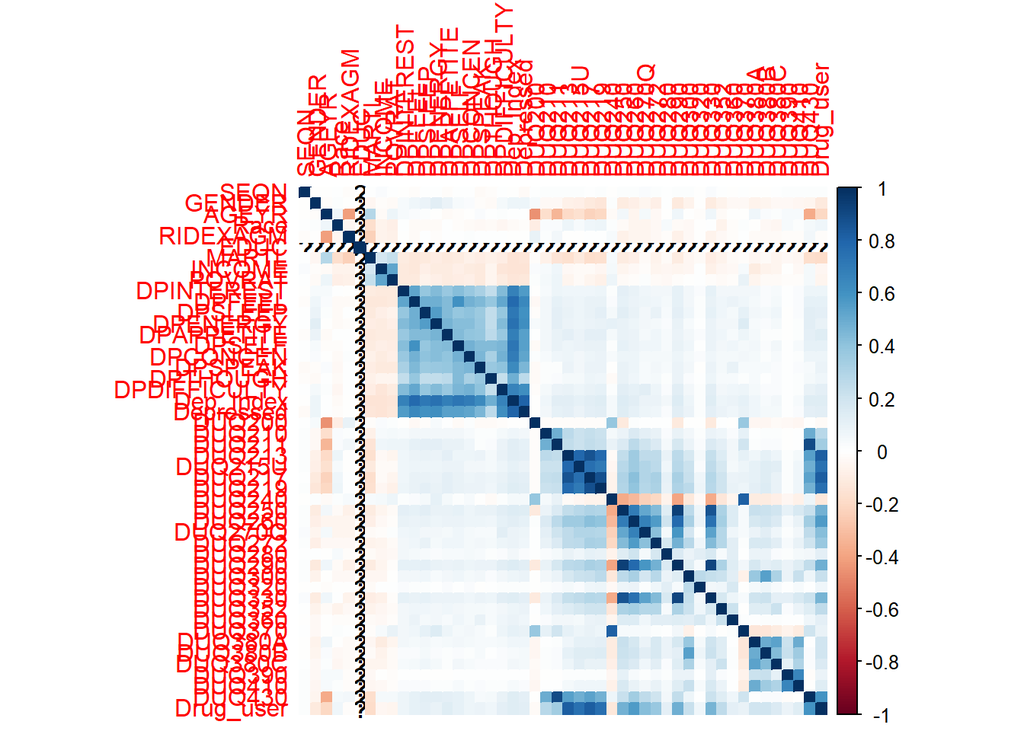

```r
library(corrplot)
corrplot(cor(DrugOnDepFinal), method = "color")
```

GRAPHICAL SUMMARIES PT 1

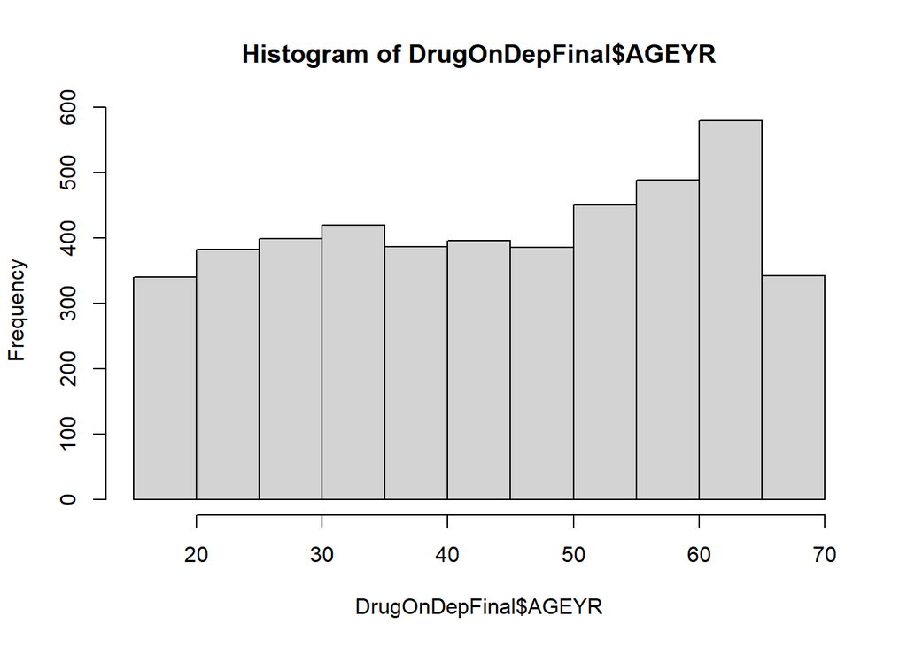

```r
library(ggplot2)
#new age distribution
hist(DrugOnDepFinal$AGEYR)
```

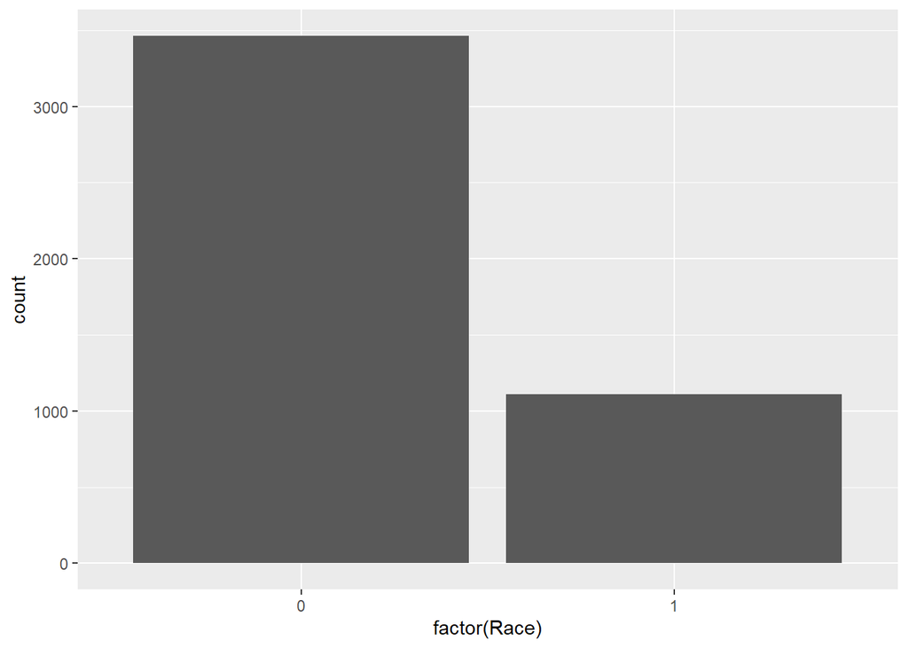

```r
#count of race (1 - Mexican American, 2 - Other Hispanic, 3-Non-Hispanic White, 4-Non-Hispanic Black, 5-Other Race - Including Multi-Racial)
ggplot(DrugOnDepFinal,aes(x=factor(Race)))+ geom_bar(position="dodge")
```

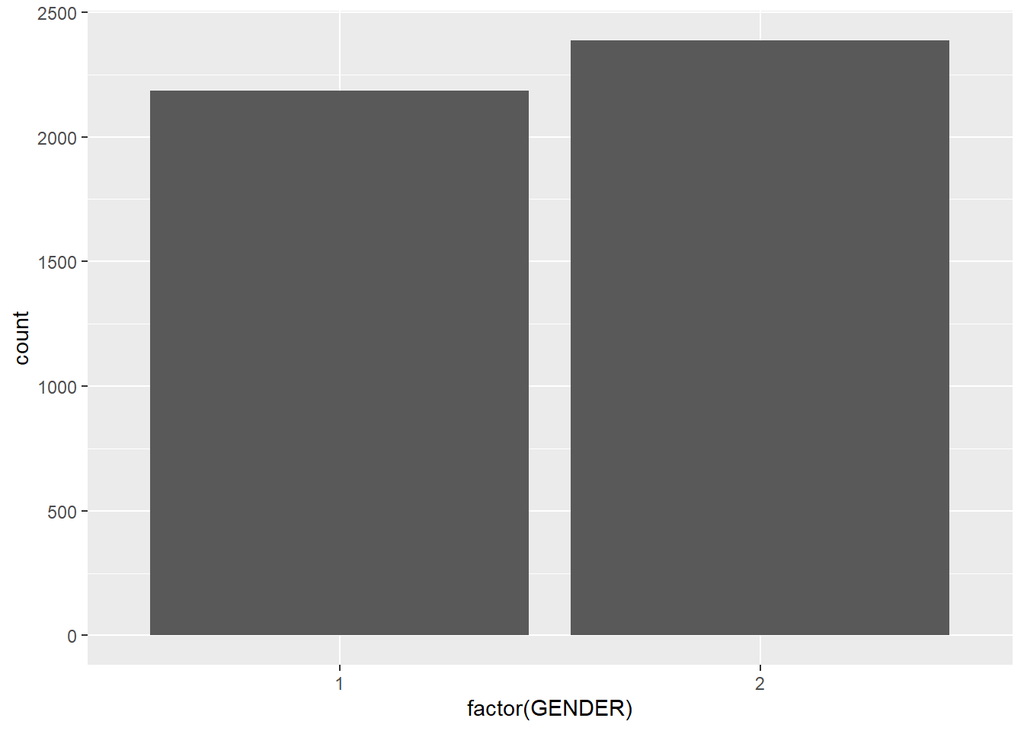

```r
#count of gender (1-MALE, 2-Female)
ggplot(DrugOnDepFinal,aes(x=factor(GENDER)))+ geom_bar(position="dodge")
```

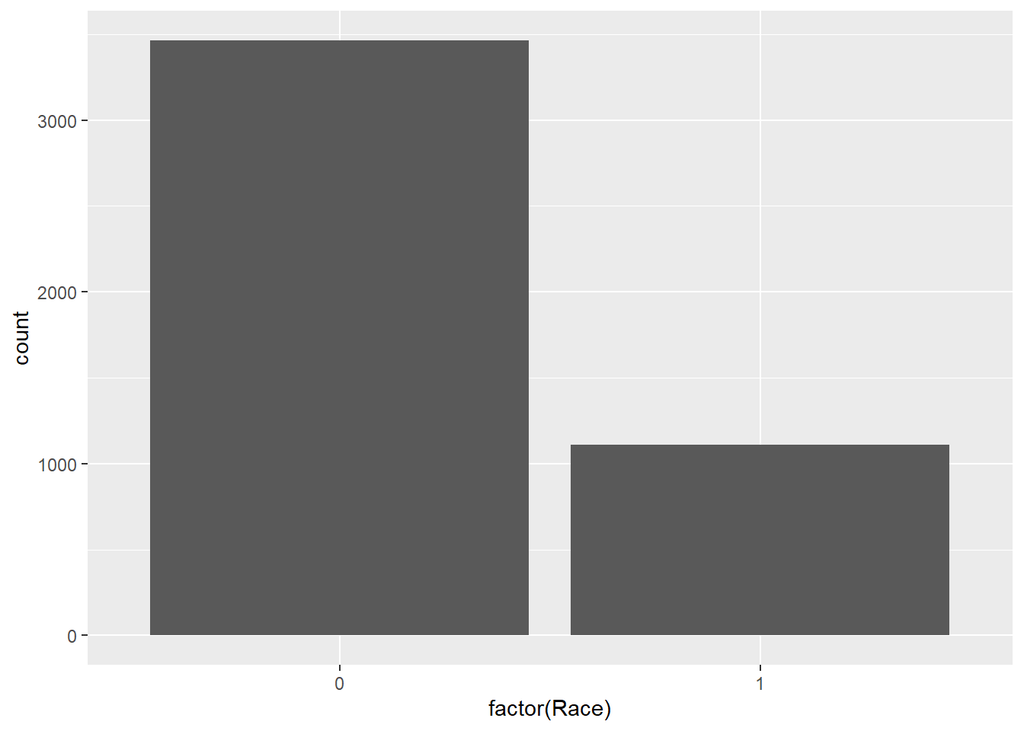

```r
#count of Race/Origin
ggplot(DrugOnDepFinal,aes(x=factor(Race)))+ geom_bar(position="dodge")
```

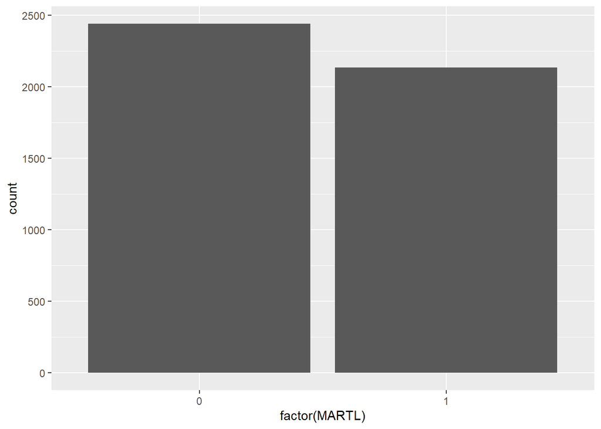

```r
#count of Marital status
ggplot(DrugOnDepFinal,aes(x=factor(MARTL)))+ geom_bar(position="dodge")
```

GRAPHICAL SUMMARIES PT 2

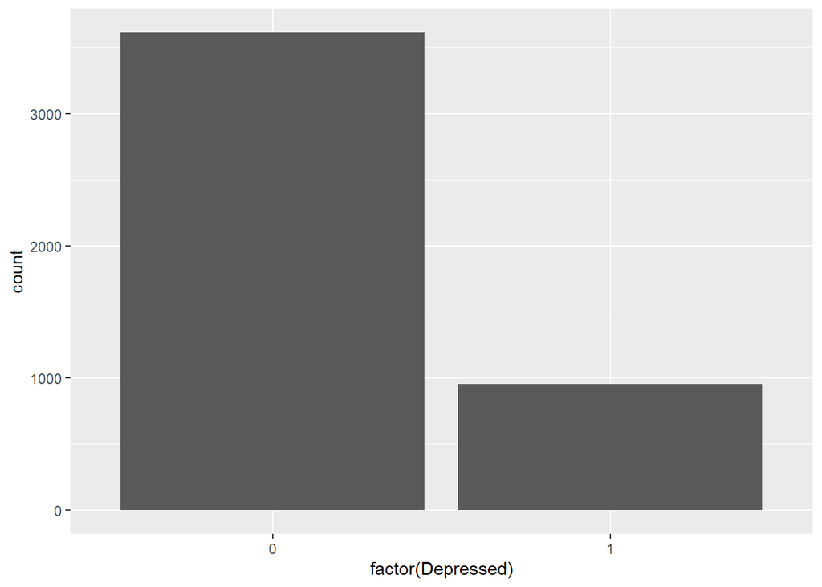

```r
#Number of people depressed
ggplot(DrugOnDepFinal,aes(x=factor(Depressed)))+ geom_bar(position="dodge")
```

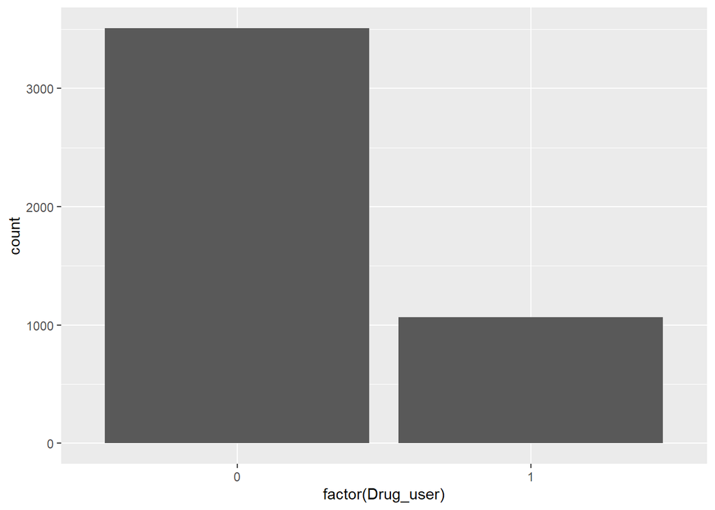

```r
#Number of people with drug use
ggplot(DrugOnDepFinal,aes(x=factor(Drug_user)))+ geom_bar(position="dodge")
```

LOGISTIC REGRESSION - MODEL 1

```r
library(AICcmodavg)

#partition data
set.seed(2)
train.index <- sample(c(1:dim(DrugOnDepFinal)[1]), dim(DrugOnDepFinal)[1]*0.7)
train.df <- DrugOnDepFinal[train.index, ]
valid.df <- DrugOnDepFinal[-train.index, ]

#run logistic regression
logit.reg <- glm(Drug_user~Depressed+ GENDER+ Race+ EDUC+ MARTL+ POVRAT, data = train.df, family = 'binomial')
options(scipen=999)
summary(logit.reg)
```

```
##
## Call:
## glm(formula = Drug_user ~ Depressed + GENDER + Race + EDUC +
##     MARTL + POVRAT, family = "binomial", data = train.df)
##
## Deviance Residuals:
##     Min       1Q   Median       3Q      Max
## -1.2667  -0.7439  -0.6150  -0.4467   2.1726
##
## Coefficients:
##             Estimate Std. Error z value             Pr(>|z|)
## (Intercept) -0.10954    0.15378  -0.712              0.47627
## Depressed    0.65794    0.10144   6.486    0.000000000088358 ***
## GENDER      -0.65949    0.08789  -7.504    0.000000000000062 ***
## Race         0.25803    0.09800   2.633              0.00847 **
## EDUC         0.01821    0.09231   0.197              0.84364
## MARTL       -0.83238    0.09348  -8.905 < 0.0000000000000002 ***
## POVRAT       0.00848    0.02751   0.308              0.75791
## ---
## Signif. codes:  0 '***' 0.001 '**' 0.01 '*' 0.05 '.' 0.1 ' ' 1
##
## (Dispersion parameter for binomial family taken to be 1)
##
##     Null deviance: 3484.3  on 3198  degrees of freedom
## Residual deviance: 3280.6  on 3192  degrees of freedom
##   (1 observation deleted due to missingness)
## AIC: 3294.6
##
## Number of Fisher Scoring iterations: 4
```

MODEL 2

```r
logit.reg2 <- glm(Drug_user~Depressed+ GENDER+ MARTL+ Race, data = train.df, family = 'binomial')
options(scipen=999)
summary(logit.reg2)
```

```
##
## Call:
## glm(formula = Drug_user ~ Depressed + GENDER + MARTL + Race,
##     family = "binomial", data = train.df)
##
## Deviance Residuals:
##     Min       1Q   Median       3Q      Max
## -1.2489  -0.7435  -0.6150  -0.4527   2.1583
##
## Coefficients:
##             Estimate Std. Error z value             Pr(>|z|)
## (Intercept) -0.08898    0.14369  -0.619              0.53574
## Depressed    0.65365    0.10066   6.493   0.0000000000839039 ***
## GENDER      -0.65729    0.08767  -7.497   0.0000000000000652 ***
## MARTL       -0.82318    0.09163  -8.984 < 0.0000000000000002 ***
## Race         0.25905    0.09755   2.655              0.00792 **
## ---
## Signif. codes:  0 '***' 0.001 '**' 0.01 '*' 0.05 '.' 0.1 ' ' 1
##
## (Dispersion parameter for binomial family taken to be 1)
##
##     Null deviance: 3484.9  on 3199  degrees of freedom
## Residual deviance: 3281.6  on 3195  degrees of freedom
## AIC: 3291.6
##
## Number of Fisher Scoring iterations: 4
```

MODEL Comparison K: The number of parameters in the model. AICc: The AIC value of the model. model that explains the most variation in the data has lower value Delta_AICc: The difference between the AIC of the best model compared to the current model being compared. AICcWt: The proportion of the total predictive power that can be found in the model. Cum.Wt: The cumulative sum of the AIC weights. LL: The log-likelihood of the model. This tells us how likely the model is, given the data we used.

MODEL 2 Offers a better fit

```r
#List of models
models <- list(logit.reg, logit.reg2)

#model names
mod.names <- c('dep.gen.rac.educ.martl.pov','dep.gen.martl' )

#Calculate AIC
aictab(cand.set = models, modnames = mod.names)
```

```
##
## Model selection based on AICc:
##
##                            K    AICc Delta_AICc AICcWt Cum.Wt       LL
## dep.gen.martl              5 3291.60       0.00   0.82   0.82 -1640.79
## dep.gen.rac.educ.martl.pov 7 3294.65       3.05   0.18   1.00 -1640.31
```

ACCESSING THE MODEL McFadden’s R2, which ranges from 0 to just under 1. Values close to 0 indicate that the model has no predictive power. In practice, values over 0.40 indicate that a model fits the data very well.

```r
library(caret)
#PREDICTIVE POWER
pscl::pR2(logit.reg2)["McFadden"]
```

```
## fitting null model for pseudo-r2
```

```
##   McFadden
## 0.05833019
```

```r
pscl::pR2(logit.reg)["McFadden"]
```

```
## fitting null model for pseudo-r2
```

```
##   McFadden
## 0.05846401
```

```r
#COMPUTE IMPORTANCE OF EACH VARIABLE
caret::varImp(logit.reg)
```

```
##             Overall
## Depressed 6.4856358
## GENDER    7.5038355
## Race      2.6329248
## EDUC      0.1972357
## MARTL     8.9045640
## POVRAT    0.3082307
```

```r
#VIF - VALUE OVER 5 IS SEVERE multicollinearity
car::vif(logit.reg2)
```

```
## Depressed    GENDER     MARTL      Race
##  1.028362  1.018499  1.037879  1.022086
```

MAKE Predictions

a Depressed status of “Yes” has a probability of being a drug user of .3796. Conversely, an individual with the same gender, race, martl, educ, and poverty rate but with a depression status of “No” has a probability of being a drug user of 0.2414

```r
#define two individuals
new <- data.frame(GENDER = 2, Race = 1, MARTL = 0, EDUC = 0, POVRAT = 2.17, Depressed = c(1, 0))

#Predicted probability
predict(logit.reg2, new, type = "response")
```

```
##         1         2
## 0.3796904 0.2414937
```

MODEL DIAGNOSTIC

```r
Predicted <- predict(logit.reg2, valid.df, type = 'response')

u <- union(Predicted, valid.df$Drug_user)
t <- table(factor(Predicted, u),factor(valid.df$Drug_user, u))

confusionMatrix(t)
```

[output not shown]

[output cut: 162 more lines]

[output not shown]

```r
#install.packages('gains')
library(caret)
library(gains)
gain <- gains(valid.df$Drug_user, Predicted, groups= 100)
```

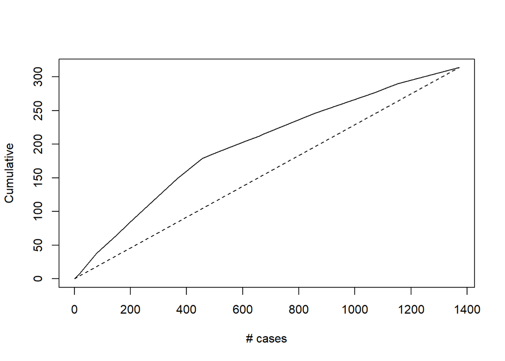

```r
#LIFT CHART
plot(c(0, gain$cume.pct.of.total*sum(valid.df$Drug_user))~c(0,gain$cume.obs),
xlab="# cases", ylab="Cumulative", main="", type="l")
lines(c(0,sum(valid.df$Drug_user))~c(0, dim(valid.df)[1]), lty=2)
```

#Simultaneous Equations Model#

the endogenous variables are $Depression$ and $Druguser$.

the exogenous variables are the indicator variables for demographics of the user.

the identification variable for the drug user equation are gender, martial status and income , which will only show up in the depression equation but not in the drug user equation;

```r
#Creating Drug Prices variables
DrugOnDepFinal$Marij_price <- ifelse(DrugOnDepFinal$DUQ200=="1",7.38, 0)
DrugOnDepFinal$Cocaine_price <- ifelse(DrugOnDepFinal$DUQ250=="1",84.00, 0)
DrugOnDepFinal$Heroin_price <- ifelse(DrugOnDepFinal$DUQ290=="1",69.00, 0)
DrugOnDepFinal$Meth_price <- ifelse(DrugOnDepFinal$DUQ330=="1",40.00, 0)

view(DrugOnDepFinal)
```

```r
#install.packages('systemfit')
library(systemfit)
DrugOnDep.DU <- Drug_user~Depressed+Marij_price+Cocaine_price+Heroin_price+Meth_price
DrugOnDep.Dep <- Depressed ~ Drug_user+GENDER+MARTL+INCOME

DrugOnDep.eqs <- list(DrugOnDep.DU,DrugOnDep.Dep)
DrugOnDep.ivs <- ~Marij_price+Cocaine_price+Heroin_price+Meth_price+GENDER+MARTL+INCOME
DrugOnDep2SLS <-systemfit(DrugOnDep.eqs, method= "2SLS",
                          inst=DrugOnDep.ivs, data= DrugOnDepFinal)

summary(DrugOnDep2SLS)
```

```
##
## systemfit results
## method: 2SLS
##
##           N   DF     SSR  detRCov   OLS-R2 McElroy-R2
## system 9144 9133 1112.25 0.011778 0.292681   0.467351
##
##        N   DF     SSR      MSE     RMSE       R2   Adj R2
## eq1 4572 4566 386.241 0.084591 0.290845 0.526889 0.526371
## eq2 4572 4567 726.009 0.158969 0.398709 0.039799 0.038958
##
## The covariance matrix of the residuals
##            eq1        eq2
## eq1  0.0845907 -0.0408551
## eq2 -0.0408551  0.1589685
##
## The correlations of the residuals
##           eq1       eq2
## eq1  1.000000 -0.352314
## eq2 -0.352314  1.000000
##
##
## 2SLS estimates for 'eq1' (equation 1)
## Model Formula: Drug_user ~ Depressed + Marij_price + Cocaine_price + Heroin_price +
##     Meth_price
## Instruments: ~Marij_price + Cocaine_price + Heroin_price + Meth_price + GENDER +
##     MARTL + INCOME
##
##                   Estimate   Std. Error  t value               Pr(>|t|)
## (Intercept)   -0.031498545  0.010587155 -2.97517              0.0029436 **
## Depressed      0.149813717  0.056620856  2.64591              0.0081751 **
## Marij_price    0.061048606  0.001416135 43.10933 < 0.000000000000000222 ***
## Cocaine_price  0.004308407  0.000195478 22.04036 < 0.000000000000000222 ***
## Heroin_price   0.003396203  0.000455006  7.46409    0.00000000000009992 ***
## Meth_price     0.002229905  0.000569330  3.91672    0.00009107414204301 ***
## ---
## Signif. codes:  0 '***' 0.001 '**' 0.01 '*' 0.05 '.' 0.1 ' ' 1
##
## Residual standard error: 0.290845 on 4566 degrees of freedom
## Number of observations: 4572 Degrees of Freedom: 4566
## SSR: 386.240995 MSE: 0.084591 Root MSE: 0.290845
## Multiple R-Squared: 0.526889 Adjusted R-Squared: 0.526371
##
##
## 2SLS estimates for 'eq2' (equation 2)
## Model Formula: Depressed ~ Drug_user + GENDER + MARTL + INCOME
## Instruments: ~Marij_price + Cocaine_price + Heroin_price + Meth_price + GENDER +
##     MARTL + INCOME
##
##               Estimate Std. Error  t value               Pr(>|t|)
## (Intercept)  0.1635764  0.0244160  6.69955      0.000000000023441 ***
## Drug_user    0.2154265  0.0197290 10.91930 < 0.000000000000000222 ***
## GENDER       0.0763894  0.0120061  6.36256      0.000000000217873 ***
## MARTL       -0.0555825  0.0124303 -4.47153      0.000007954601208 ***
## INCOME      -0.1214112  0.0145234 -8.35970 < 0.000000000000000222 ***
## ---
## Signif. codes:  0 '***' 0.001 '**' 0.01 '*' 0.05 '.' 0.1 ' ' 1
##
## Residual standard error: 0.398709 on 4567 degrees of freedom
## Number of observations: 4572 Degrees of Freedom: 4567
## SSR: 726.009211 MSE: 0.158969 Root MSE: 0.398709
## Multiple R-Squared: 0.039799 Adjusted R-Squared: 0.038958
```

```r
DrugOnDep3SLS <- systemfit(DrugOnDep.eqs, method="3SLS",
              inst=DrugOnDep.ivs, data=DrugOnDepFinal)
summary(DrugOnDep3SLS)
```

```
##
## systemfit results
## method: 3SLS
##
##           N   DF     SSR  detRCov   OLS-R2 McElroy-R2
## system 9144 9133 1111.94 0.011786 0.292877   0.466763
##
##        N   DF     SSR      MSE     RMSE       R2   Adj R2
## eq1 4572 4566 386.510 0.084650 0.290946 0.526559 0.526040
## eq2 4572 4567 725.431 0.158842 0.398550 0.040564 0.039724
##
## The covariance matrix of the residuals used for estimation
##            eq1        eq2
## eq1  0.0845907 -0.0408551
## eq2 -0.0408551  0.1589685
##
## The covariance matrix of the residuals
##            eq1        eq2
## eq1  0.0846496 -0.0407382
## eq2 -0.0407382  0.1588419
##
## The correlations of the residuals
##           eq1       eq2
## eq1  1.000000 -0.351323
## eq2 -0.351323  1.000000
##
##
## 3SLS estimates for 'eq1' (equation 1)
## Model Formula: Drug_user ~ Depressed + Marij_price + Cocaine_price + Heroin_price +
##     Meth_price
## Instruments: ~Marij_price + Cocaine_price + Heroin_price + Meth_price + GENDER +
##     MARTL + INCOME
##
##                   Estimate   Std. Error  t value               Pr(>|t|)
## (Intercept)   -0.030873815  0.010580021 -2.91812              0.0035386 **
## Depressed      0.150601549  0.056618351  2.65994              0.0078427 **
## Marij_price    0.060552560  0.001380933 43.84901 < 0.000000000000000222 ***
## Cocaine_price  0.004232901  0.000184733 22.91362 < 0.000000000000000222 ***
## Heroin_price   0.003511245  0.000426965  8.22374 0.00000000000000022204 ***
## Meth_price     0.002752412  0.000535565  5.13927 0.00000028732584533842 ***
```

[output cut: 12 more lines]

```
##     MARTL + INCOME
##
##               Estimate Std. Error  t value               Pr(>|t|)
## (Intercept)  0.2055933  0.0230634  8.91428 < 0.000000000000000222 ***
## Drug_user    0.2080646  0.0196644 10.58079 < 0.000000000000000222 ***
## GENDER       0.0564730  0.0114106  4.94919         0.000000772053 ***
## MARTL       -0.0672812  0.0117685 -5.71705         0.000000011529 ***
## INCOME      -0.1272117  0.0140355 -9.06356 < 0.000000000000000222 ***
## ---
## Signif. codes:  0 '***' 0.001 '**' 0.01 '*' 0.05 '.' 0.1 ' ' 1
##
## Residual standard error: 0.39855 on 4567 degrees of freedom
## Number of observations: 4572 Degrees of Freedom: 4567
## SSR: 725.430863 MSE: 0.158842 Root MSE: 0.39855
## Multiple R-Squared: 0.040564 Adjusted R-Squared: 0.039724
```

Hausman specification test

```r
h <- hausman.systemfit(DrugOnDep2SLS, DrugOnDep3SLS)
print(h)
```

```
##
##  Hausman specification test for consistency of the 3SLS estimation
##
## data:  DrugOnDepFinal
## Hausman = 36.715, df = 11, p-value = 0.0001286
```

X and Y (Depression and Drug user) are dependent of each other. Each variable can influence the other. This model helps correct for simultaneity

Based on the 2SLS model, the price of the 4 different drugs(marijuana, heroin, cocaine and meth) are very significant in the prediction of being a drug user.

In comparison, gender, marital status and income are also significant factor in the influence of depression.

Hausman specification test tells me to reject the 3SLS because the 2SLS is better.